# tutorial2

Look carefully at the plot of log retail sales:

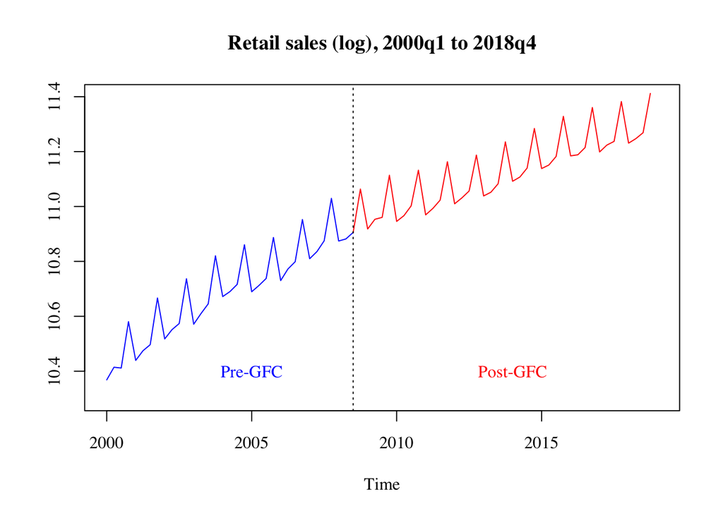

It appears that the growth in retail sales may be faster in the first half of the sample period than the second. It is plausible that the ``Great Financial Crisis’’ (GFC) of 2007/8 resulted in a permanent change in the trend of this variable. For the purposes of this tutorial, we will date the GFC at September 2008. That is, we will allow for a one-off change in the trend line to occur after 2008q3. Moreover we will restrict the change to be *continuous* at that time, implying a change in the slope of the trend but no jump/discontinuity.

1. Recall that we code the dates 2008q1 (March quarter), 2008q2 (June quarter), 2008q3 (September quarter) and 2008q4 (December quarter) in R as the numbers 2008, 2008.25, 2008.5, 2008.75 respectively. Think of these numbers of representing the *start* of each quarter, while the labels (March/June/September/December) represent the *end* of each quarter. Define the dummy variable
   $$\text{PostGFC}_t = 1(\text{Time}_t>2008.5),$$
   where $1(\text{Time}_t>2008.5)=1)$ if $\text{Time}_t>2008.5$ and 0 otherwise. Also define
   $$\text{TimePostGFC}_t = (\text{Time}_t-2008.5)\times \text{PostGFC}_t$$
   Produce a plot of $\text{TimePostGFC}_t$ for the full sample period 2000-2018.
   (Digression: $\text{TimePostGFC}_t$ can also be written $\max(0, \text{Time}_t-2008.5)$, which is an example of a ReLU function.)
2. Consider the regression specification:
   $$Y_t = \beta_0 + \beta_1 \text{Time}_t +
   \delta \text{TimePostGFC}_t + U_t.$$
   1. What is the slope coefficient of the trend line up to and including 2008q3?
   2. What is the slope coefficient of the trend line after 2008q3?
   3. Show the trend line is continuous at 2008q3.
3. Estimate Regression Model 3 for log retail sales on $\text{Time}_t$ and $\text{TimePostGFC}_t$ and plot the fitted values with the time series plot of the data. Based on this plot, which properties of log retail sales are modeled by this regression, and which properties are not modeled?
4. Estimate Regression Model 4 for log retail sales on $\text{Time}_t$, $\text{TimePostGFC}_t$ and the quarterly dummies, and plot the fitted values with the time series plot of the data. Based on this plot, which properties of log retail sales are modeled by this regression, and which properties are not modeled?
5. Obtain the residuals from each of these two regressions. Produce time series plots of each set of residuals, and comment on the patterns you observe.
6. Use each of these regressions to produce forecasts for the four quarters of 2019. Calculate the forecast errors from both sets of forecasts. What can be learned from these forecast errors?